# XAI - Homework 1 - Barbara Bugała

## Task A

Calculate Shapley values for player A given the following value function

$v(\emptyset) = 0 \\ v(A) = 20 \\ v(B) = 20 \\ v(C) = 60 \\ v(A,B) = 60 \\ v(A,C) = 70 \\ v(B,C) = 70 \\ v(A,B,C) = 100 $

contributions of player A:

$v(A) - v(\emptyset) = 20$  
$v(A,B) - v(B) = 40$  
$v(A,C) - v(C) = 10$  
$v(A,B,C) - v(B,C) = 30$

number of players $ \rightarrow |P| = 3$

shap values for player A:

$\phi_A = \frac{2}{6} *20 + \frac{1}{6}* 40 + \frac{1}{6} *10 + \frac{2}{6}* 30 = 25$

## Task B

I’ll be using the Phoneme dataset, which has 5 numerical features and a binary target variable (1 or 2) representing two phoneme classes.

|  | V1 | V2 | V3 | V4 | V5 | TARGET |
| --- | --- | --- | --- | --- | --- | --- |
| 0 | 0.489927 | -0.451528 | -1.047990 | -0.598693 | -0.020418 | 1 |
| 1 | -0.641265 | 0.109245 | 0.292130 | -0.916804 | 0.240223 | 1 |
| 2 | 0.870593 | -0.459862 | 0.578159 | 0.806634 | 0.835248 | 1 |
| 3 | -0.628439 | -0.316284 | 1.934295 | -1.427099 | -0.136583 | 1 |
| 4 | -0.596399 | 0.015938 | 2.043206 | -1.688448 | -0.948127 | 1 |

### Model Training (XGBoost)

We train an **XGBoost** model to classify the two phoneme classes.

```
The value of f(empty) is:  1.1356814
```

We approximate SHAP values using Monte Carlo sampling:

1. Start from a **baseline input**.
2. Randomly permute the feature order.
3. For each permutation:
   - Add features one by one.
   - Record how much the model output changes.
4. Average these changes across all permutations.

```
Shap for attibutions:  [-0.46673081 -0.01072917  0.26250805  0.05356276 -0.03820485]
predicted models output:  0.9360873699188232
actual model output:  0.93608737
```

Shap values from shap library

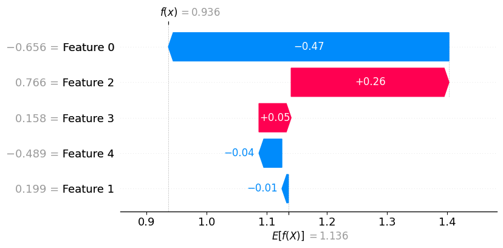

*The results are not identical, but they are quite similar. The overall impact on the final prediction of each feature seems to be preserved.*

Second example, calculation from self-made shap

```
Shap for attibutions:  [0.30533292 0.24454349 0.03187849 0.0176059  0.02070512]
predicted models output:  1.7557473182678223
actual model output:  1.7557473
```

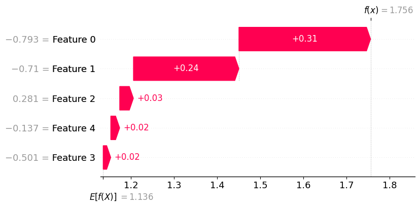

*In this example results also look very similar to the ones in the self-made shap calculation. There are small differences but it looks very good.*

## Task C

In this task, I will perform an analysis on the more imbalanced Mammography dataset. The target variable takes values in {-1, 1}, and the class imbalance is considerably higher compared to Task B.

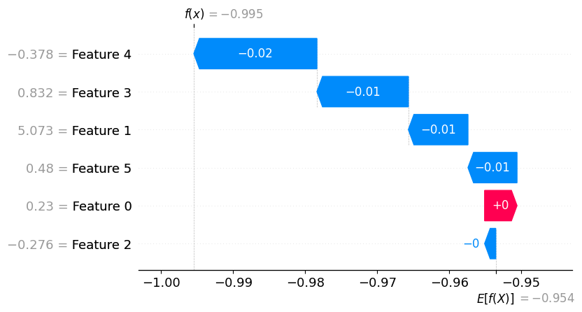

*The difference is evident: the SHAP values are substantially smaller, with the maximum absolute value usually below 0.03, whereas in the previous analysis they reached values as high as 0.5.*